# Riport

Szabó Bence, Bodrácska Márk, Sklovskiy Dávid

11/24/2019

## Program bemutatása

Ebben a riportban bemutatjuk elkészült munkánk. A cél a kőolaj különböző lejáratú termékeiből létrejött hálózat vizsgálata. Első lépésben a return_maker függvénnyel létrehozunk egy hozammátrixot a kapott kőolajadatokból. Látható az első 10 dátumra kapott hozamok mind a 24 lejáratra.

```r
return_maker()
```

```
##          Date          CL1          CL2          CL3          CL4
## 2  2010-01-02  0.000000000  0.000000000  0.000000000  0.000000000
## 3  2010-01-03  0.000000000  0.000000000  0.000000000  0.000000000
## 4  2010-01-04  0.027091734  0.026243439  0.025052710  0.024781161
## 5  2010-01-05  0.003189793  0.003531417  0.004113733  0.004812320
## 6  2010-01-06  0.017243488  0.016260163  0.015905531  0.016044061
## 7  2010-01-07 -0.006251503 -0.006686567 -0.006642154 -0.006716946
## 8  2010-01-08  0.001088797  0.001322274  0.001432836  0.002135485
## 9  2010-01-09  0.000000000  0.000000000  0.000000000  0.000000000
## 10 2010-01-10  0.000000000  0.000000000  0.000000000  0.000000000
## 11 2010-01-11 -0.002779456 -0.003481393 -0.003815429 -0.003906712
##             CL5          CL6          CL7          CL8          CL9
## 2   0.000000000  0.000000000  0.000000000  0.000000000  0.000000000
## 3   0.000000000  0.000000000  0.000000000  0.000000000  0.000000000
## 4   0.024145116  0.023386114  0.022900763  0.022793054  0.022686352
```

[output cut: 40 more lines]

Ezután hozzáadjuk a paramétereket(kezdő dátum, késleltetés, ablakméret), és ezeket ellenőrizzük. Ha valami nem stimmel, a program hibaüzenetet ír ki.

```r
add_parameters(2010-01-30,0,20)
check_parameters()
```

```
## [1] "Character formátumba adja meg a kezdő és végdátumokat pl: \"2010-01-01\""
```

```
## [1] FALSE
```

```r
add_parameters("1990-02-07",0,20)
check_parameters()
```

```
## [1] "Kérjük olyan dátumot adjon meg, ami az elemzés intervallumába beleesik:"
```

```
## [1] FALSE
```

```r
add_parameters("2011-01-30",-5,20)
check_parameters()
```

```
## [1] TRUE
```

```r
add_parameters("2011-01-30",0,20)
check_parameters()
```

```
## [1] TRUE
```

A következő lépés a korrelációs mátrix kiszámolása. Minden eszközt mindennel összepárosítunk, a számolást a calculate_correlation függvény végzi, a mátrix után kiszámolja az adott napok átlagát, maximumát, minimumát.

```r
calculate_correlation()
```

A plot_mmm függvény a három idősort ábrázolja(átlag, maximum, minimum). Ezen ábra segítségével már egy kezdőleges képet kaphatunk a hálózat összekötöttségéről.

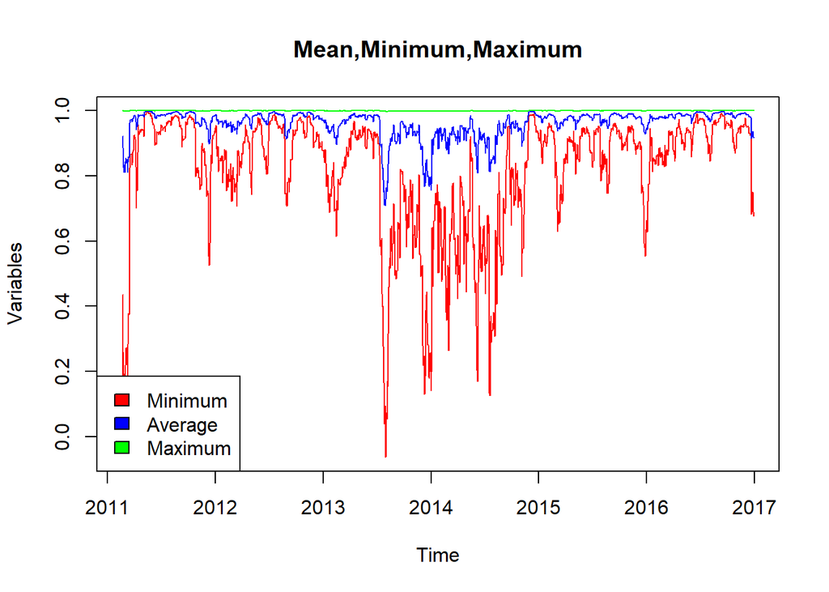

```r
plot_mmm()
```

Végül a hálozatot ábrázoljuk kétféle plot-tal. Ehhez ki kell választanunk egy bizonyos napot, amire meg szeretnénk nézni az adott napi hálót. Az első(a graph_plot() függvény használatával) egy gráfszerű ábra, ahol a színek és a vastagságok jelzik a korreláció erősségét.

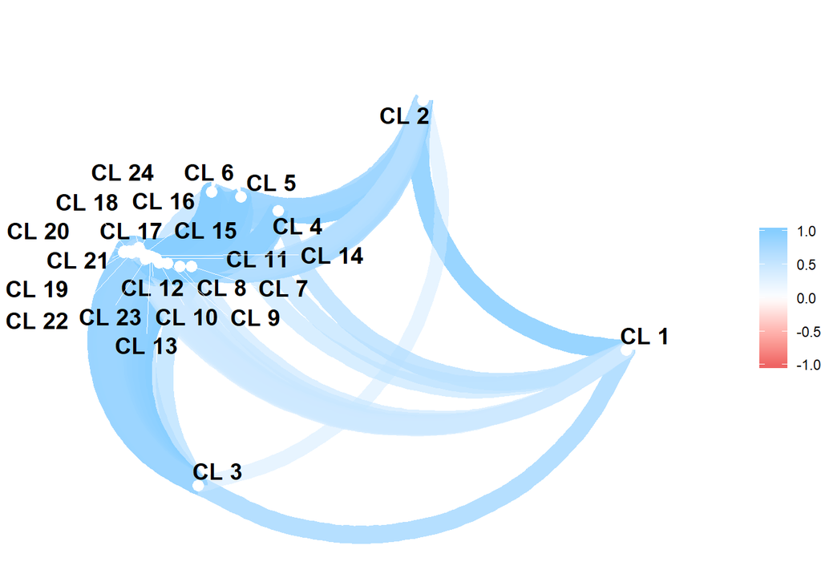

```r
graph_plot(3)
```

A másik pedig egy hőtérkép, amely a korrelációs mátrix mezőit színezi be a korreláció nagyságától és irányától függően.

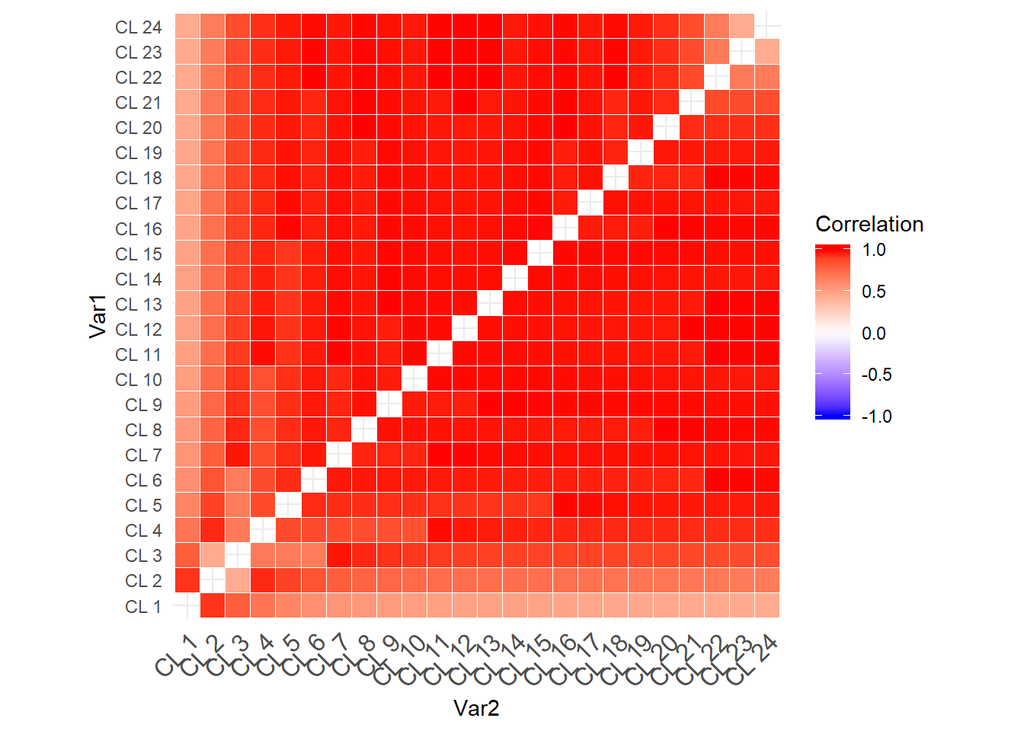

```r
heatmap(3)
```

## Elemzés

A következőkben megnézzük, hogy a hálózat hogyan reagál különböző paraméterezésekre, és ezek milyen érdekességeket fognak eredményezni.

```r
add_parameters("2011-01-30",0,360)
check_parameters()
```

```
## [1] TRUE
```

```r
calculate_correlation()
```

Minimum, maximum és átlag korreláció ettől a naptól nézve 2016.12.31-ig (mivel az ablak mérete 1 év, az első adat egy évvel később mutatkozik):

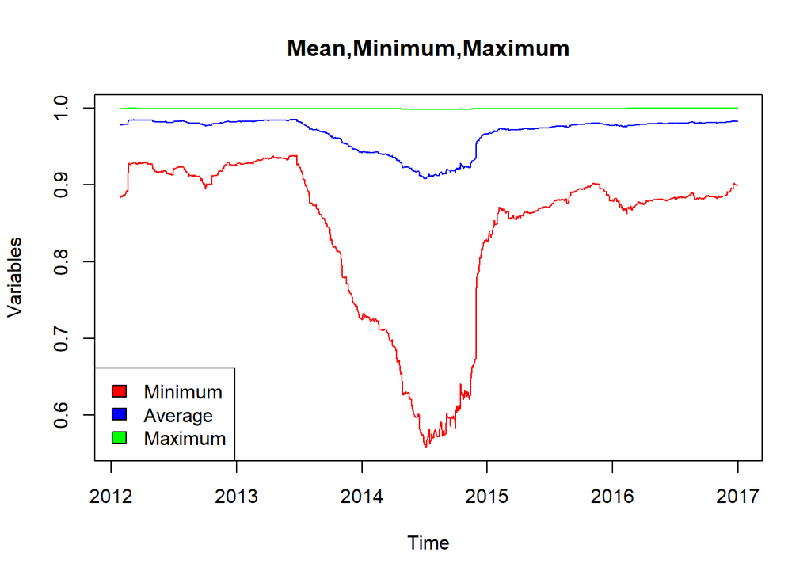

```r
plot_mmm()
```

A ploton jól látszik a 0 késleltetés következménye: az egymáshoz közeli lejáratú szerződések árai között közel 1-es korreláció figyelhető meg, emiatt a maximum végig 1. Emellett a minimum 2014 és 2015 között a legkisebb, de még így sem éri el soha a 0,5-ös korrelációt, azaz végig legalább közepesen erős maradt. Egyébként, ahogy azt majd később látni fogjuk, a korreláció gyengülése a rövid lejáratú, CL1-CL6 eszközökhöz köthető.

Az alábbi ábrán a pontok egymástól való távolsága, a kapcsolatok színe és vastagsága jelzi a korreláció erősségét. Ahogy a plotból is látszik, az első pár évben nagyon erős a korreláció:

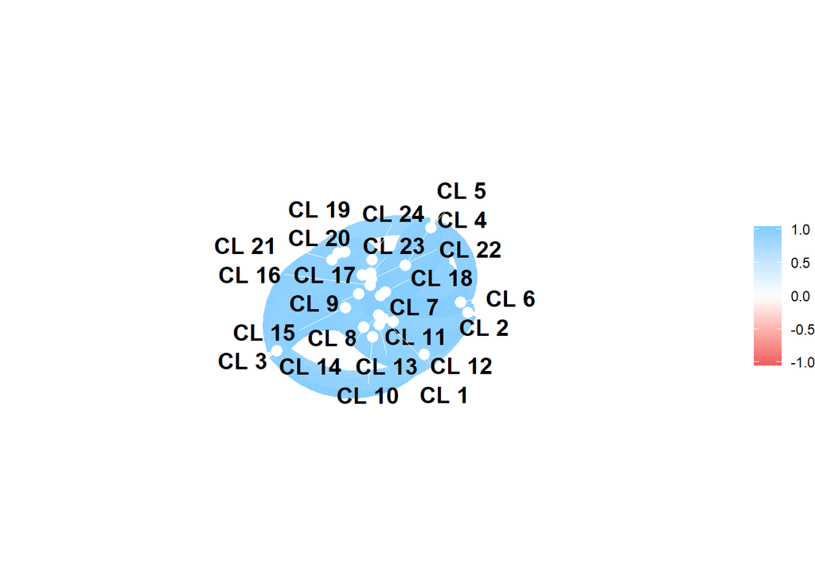

```r
graph_plot(300)
```

Az élénk píros hőtérkép is ezt igazolja:

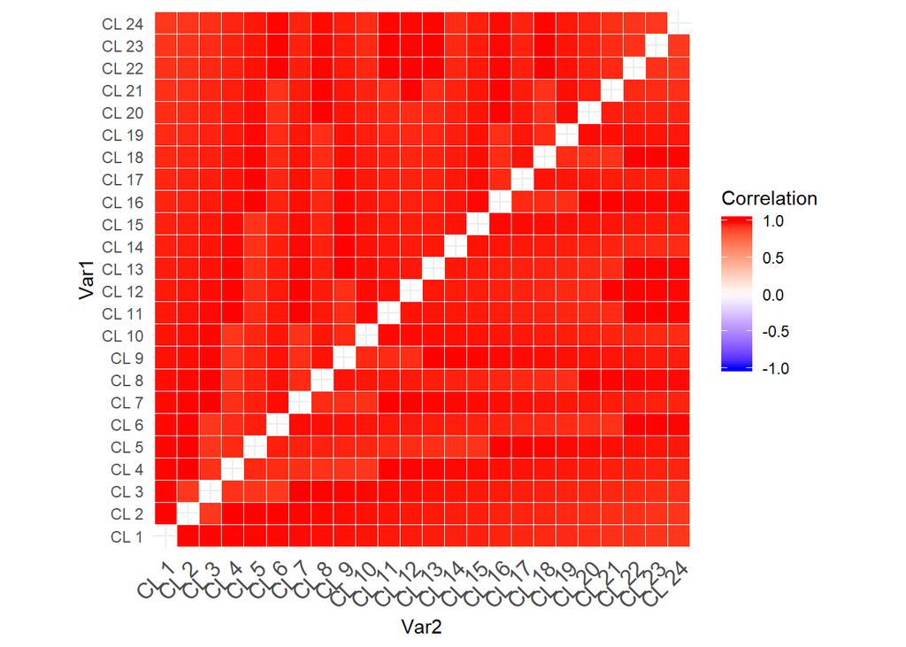

```r
heatmap(300)
```

2014 és 2015 gyengébb a kapcsolat, de amint látjuk, ezt csak az 1-6 hónapos lejáratú szerződések okozzák, amelyekből 1-3 lejáratúak egy-egy önálló klasztert, illetve 4-6 egy együttes klasztert alakítanak.

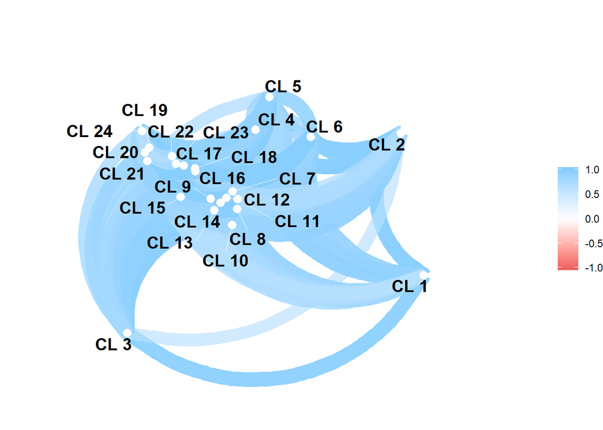

```r
graph_plot(1000)
```

Ez érdekes megfigyelés, hiszen azt várjuk, hogy az egymáshoz közel közel levő, ráadásul rövid lejáratú szerződések korrelációja nagyon magas, ha nem a legmagasabb lesz.

Az itt-ott “gyengülő korreláció” a hőtérképen is látható a világosabb cellák alakjában, de ez még mindig jóval meghaladja a 0-t:

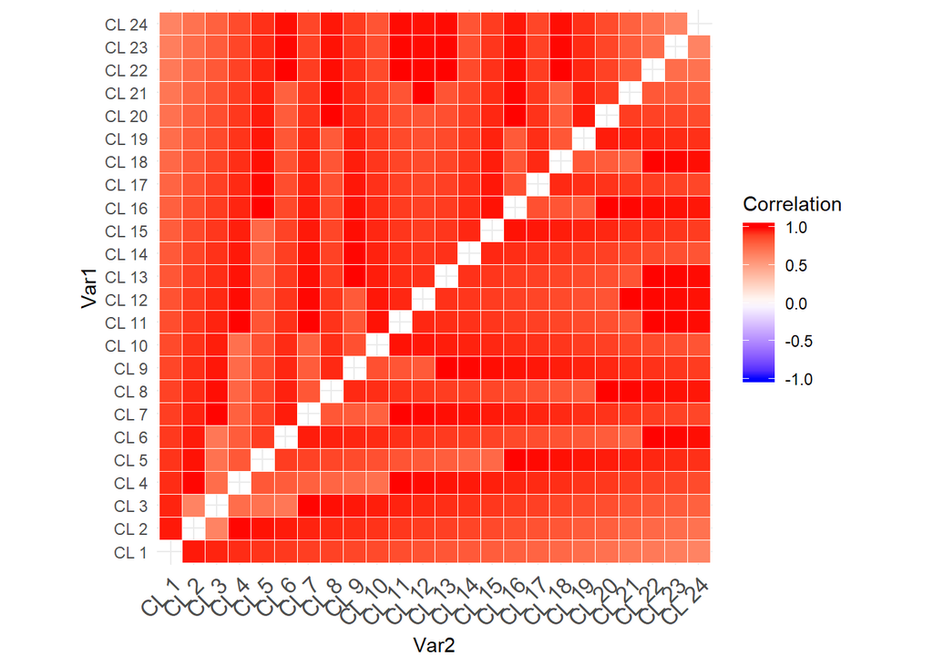

```r
heatmap(1000)
```

Most megpróbáljuk azonos ablakmérettel és induló dátummal, de egy nagyon kicsit emelve a késleltetést, pontosan 2 nappal:

```r
add_parameters("2011-01-30",2,360)
check_parameters()
```

```
## [1] TRUE
```

```r
calculate_correlation()
```

A változás drasztikus, a korrelációk nulla körül ingadoznak:

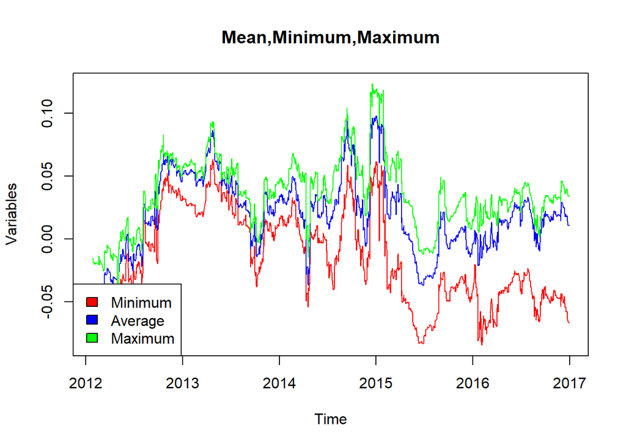

```r
plot_mmm()
```

A kapcsolati ábra is ezt igazolja. Még a legnagyon korrelációval rendelkező időpotban (2015) sem veszünk észre egyértelmű klasztereket, a kapcsolati vonalak színei teljesen fehérek.

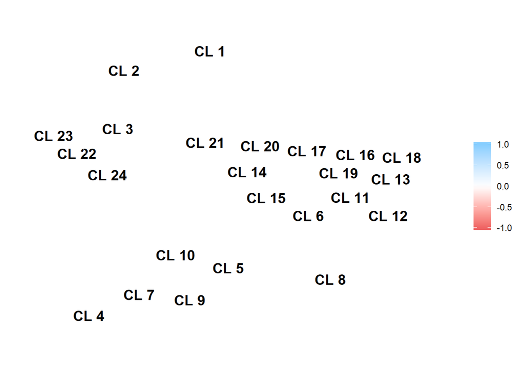

```r
graph_plot(1080)
```

A hőtérkép minimális pozitív korrelációt mutat (nagyon halvány rózsaszín):

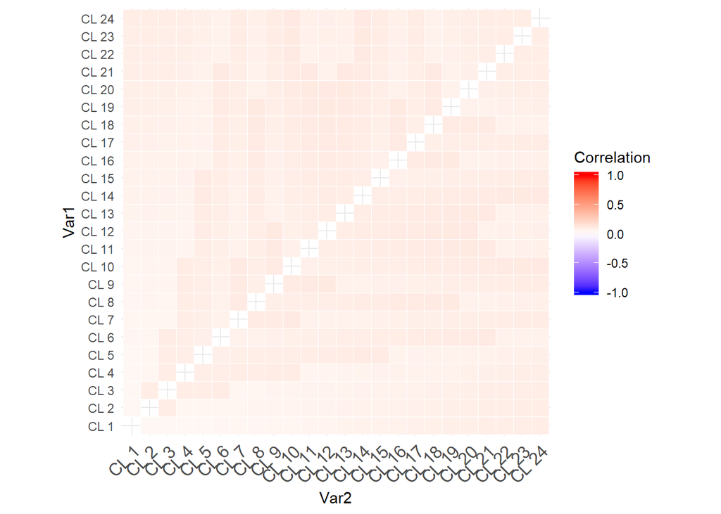

```r
heatmap(1080)
```

A korrelációs mátrixot kiszámító függvényünk úgy van megírva, hogy az output mátrixban egy CLi eszköz korrelációja csak CL(i+j)-kel van kiszámolva, CL(i-j)-kel nem. Ez késleltetés hiányában nem jelent semmit, de késleltetés jelenlétében ez azt jelenti, hogy CL(i-j) nem volt késleltetve CLi-hez képest (pl.: CL1-CL2 korrelációt találunk, de CL2-CL1-t nem). Ez a megoldás az ábrák átláthatósága érdekében lett kiválasztva (különben késleltetésekkel számított korrelációk kétszer lennének jelen az ábrákon).

Ezért most nézzük meg az előző példát, de a másik irányba: 2 nappal később kezdjük az idősort, de késleltetésünk -2. Így megkapjuk a korrelációk másik felét is:

```r
add_parameters("2011-02-01",-2,360)
check_parameters()
```

```
## [1] TRUE
```

```r
calculate_correlation()
```

Nem túl meglepő módon hasonló eredményeket kapunk:

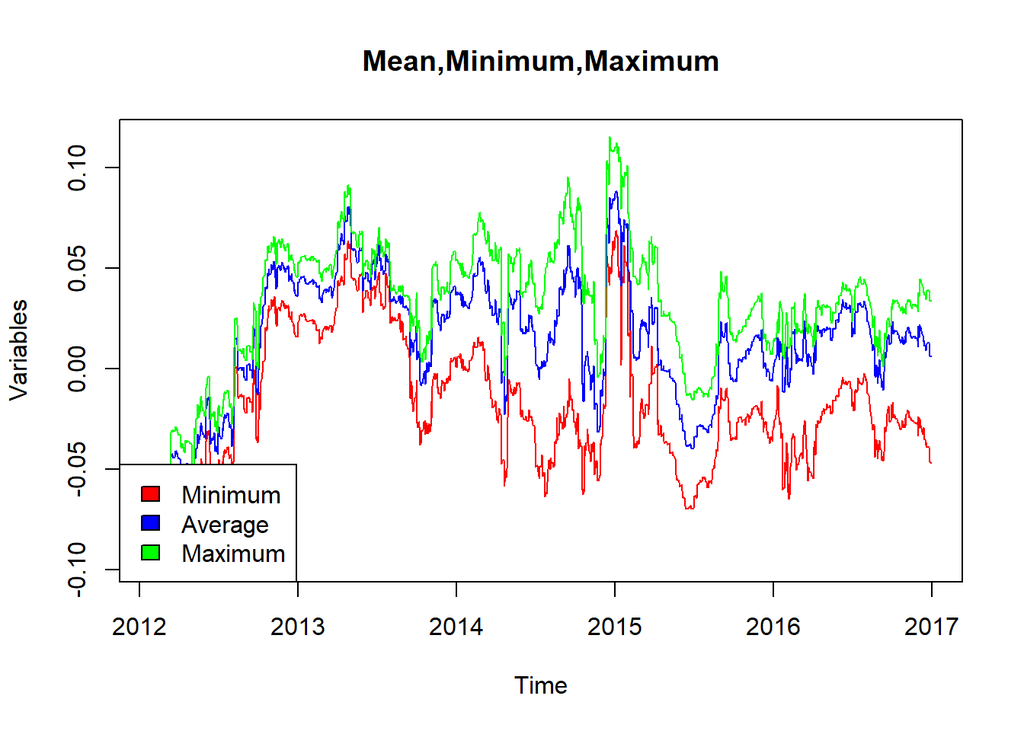

```r
plot_mmm()
```

CL1 látszólag nagyon kiszakadt a többi eszköz közül, ám erről sem tudunk sokat mondani a kapcsolati vonalak híján:

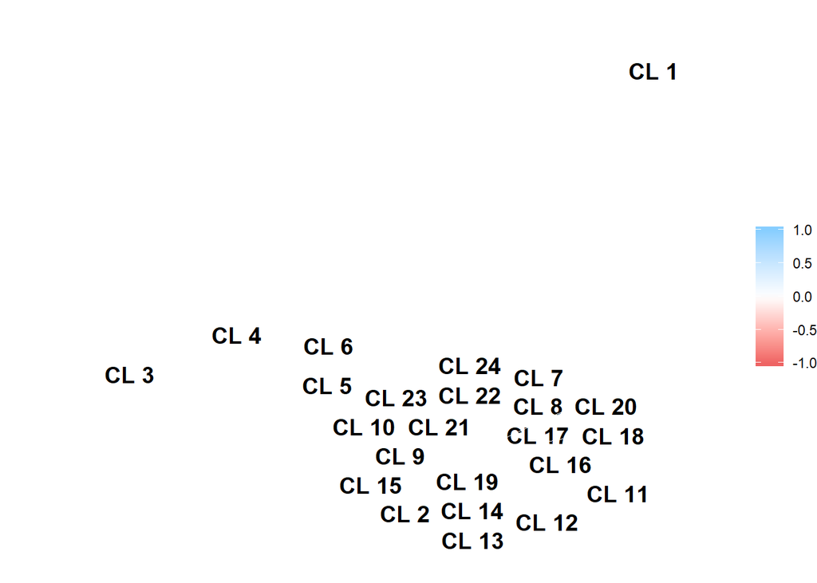

```r
graph_plot(1080)
```

Hőtérkép:

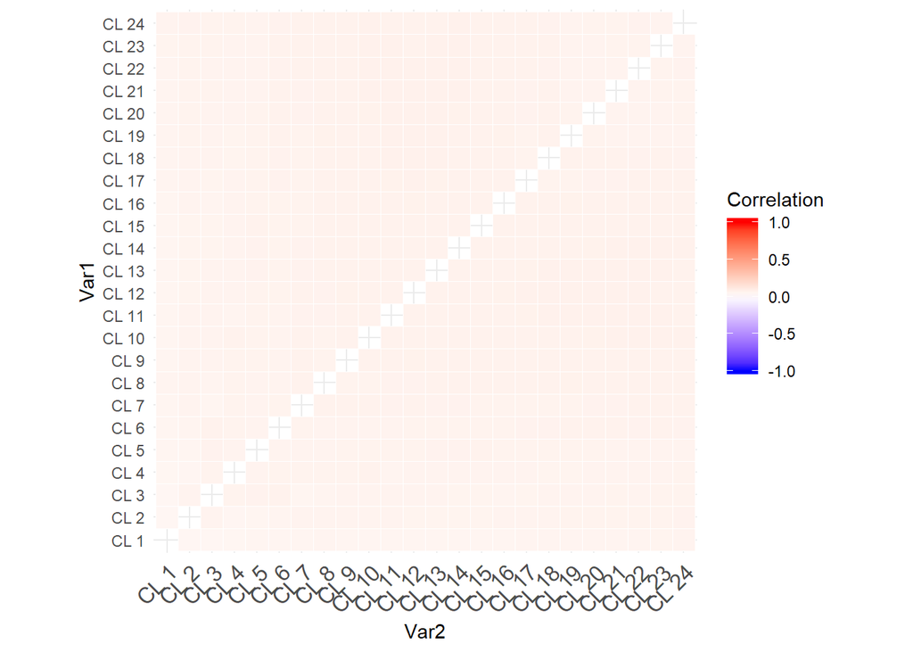

```r
heatmap(1080)
```

Most szűkítsük le az ablakméretet, pl.: 20 napra és vegyünk hasonlóan alacsony késleltetést:

```r
add_parameters("2011-02-01",1,20)
check_parameters()
```

```
## [1] TRUE
```

```r
calculate_correlation()
```

Észrevehető, hogy itt a korreláció viszont többnyire negatív:

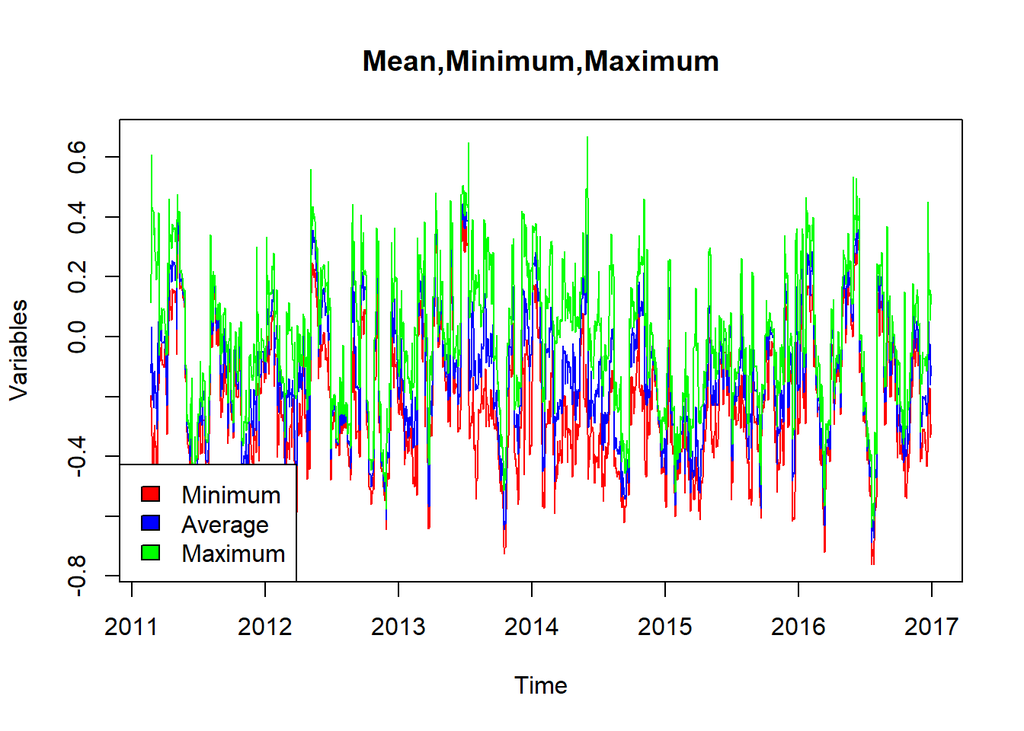

```r
plot_mmm()
```

Ezt igazolja a kapcsolati ábra:

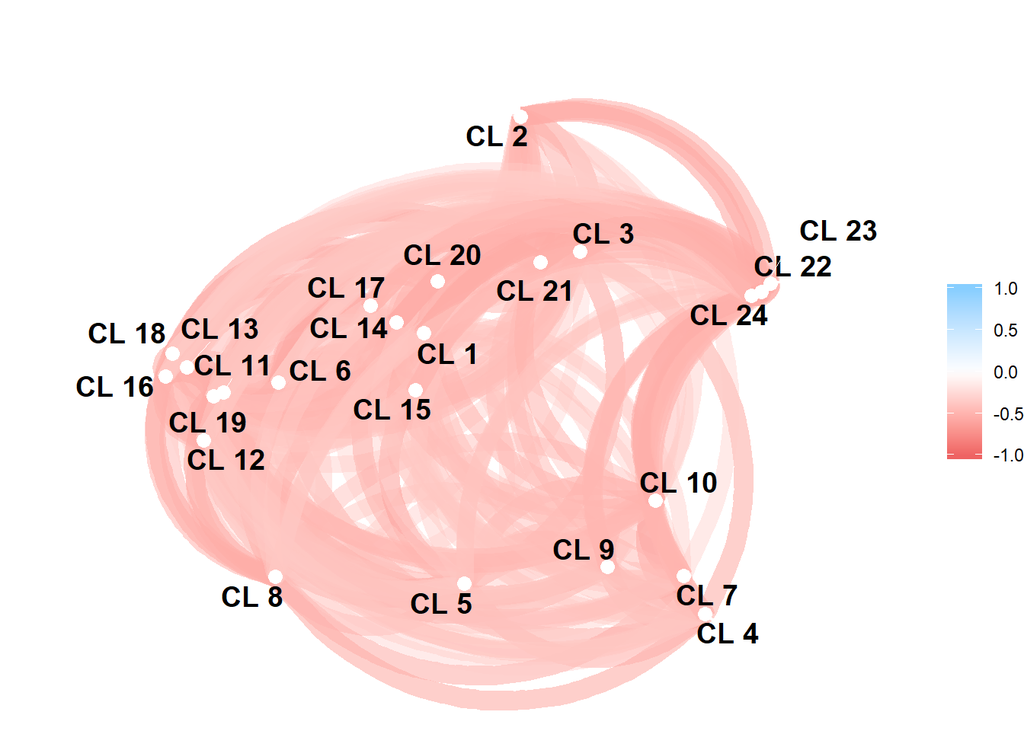

```r
graph_plot(1080)
```

És a hőtérkép is:

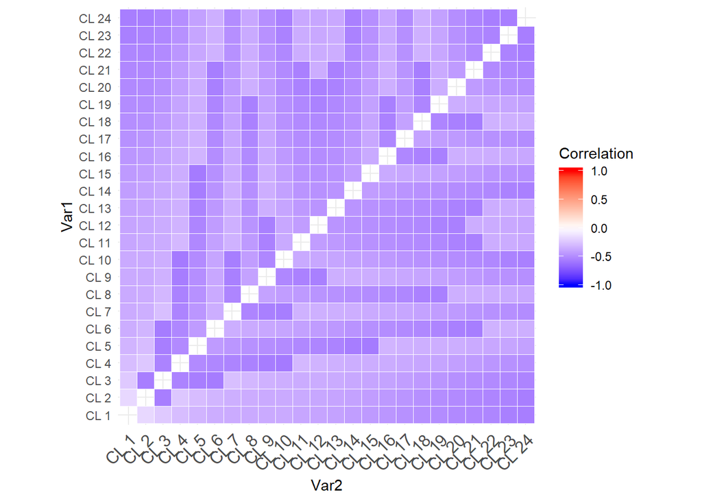

```r
heatmap(1080)
```